# Time Series Coursework 1

Yuchen Xiao 200932400

2024-03-15

## 1. Data Background and Purpose of the Project

### 1.1 Southern Oscillation Index data

The dataset that I am using is the time series “soi” from library(astsa). The **Southern Oscillation Index (SOI)** is a standardized index based on the observed sea level pressure differences between Tahiti and Darwin, Australia. It records the SOI for a period of 453 months over the years 1950-1987. The aim of this project is to fit a model to the soi data with the Prophet forecasting system. We can then predict future values using the predict function.

### 1.2 How SOI is calculated

$SOI = \frac{sSLP_{Tahiti} - sSLP_{Darwin}}{\sigma_{monthly}}$

where

$sSLP = \frac{aSLP — mSLP}{\sigma}$,

$\sigma = \sqrt{\Sigma(aSLP - mSLP)^2/N}$

and

$\sigma_{monthly} = \sqrt{\Sigma(sSLP_{Tahiti}-sSLP_{Darwin})^2/N}$

*SLP* = Sea Level Pressure, *sSLP* = standard SLP, *aSLP* = actual SLP, *mSLP* = mean SLP,

### 1.3 Initial observations

Some graphs plotted with decomposition and dygraph.

```r
library(astsa)
```

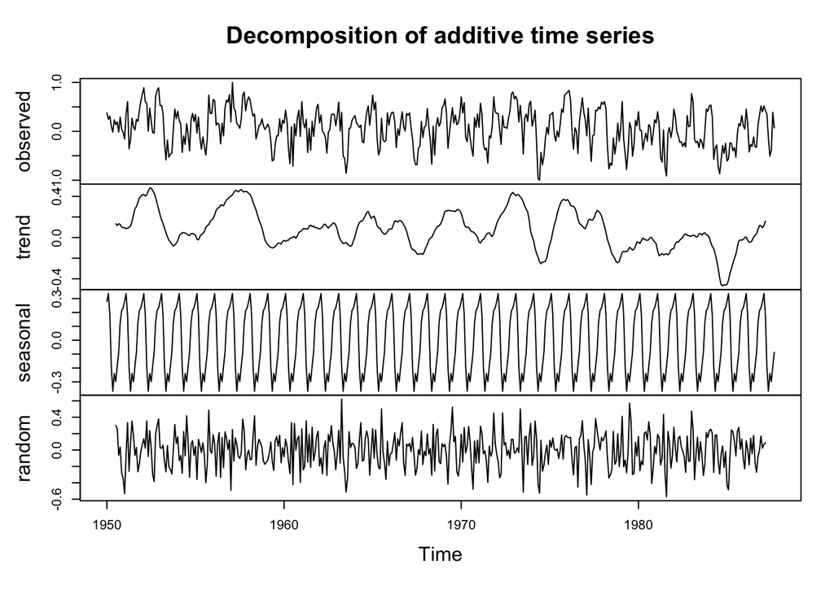

```r
plot(decompose(soi))

library(dygraphs)
```

```r
dygraph(soi, main = "SOI dygraph", xlab = "Year", ylab = "Southern Oscillation Index")%>%
  dyRangeSelector(dateWindow = c("1950-01-01", "1970-01-01"))
```

[interactive chart not shown]

From the decomposition and dygraph we can observe that the SOI is often lowest in May and July, highest in February. This is intuitive since May to July is winter and February is summer in Australia. There is obvious **yearly seasonality** in the dataset.

There is no overall upward or downward **trend** but the trend shows some periodicity.

Our **noise** seems homoskedastic which indicates that this time series is **stationary**.

## 2. Predicting future SOI data using Prophet.

I ran **install.packages(“remotes”)** and **remotes::install_github(’facebook/prophet@*release’, subdir=‘R’)**

```r
library(prophet)
```

2.1 Set soi as an R dataframe with the time column called ds and the data column called y.

```r
soi.df = data.frame(ds=zoo::as.yearmon(time(soi)), y=soi)
```

2.2. Run *m = prophet(d)*.

```r
model = prophet(soi.df, weekly.seasonality = FALSE, daily.seasonality = FALSE)
```

2.3. Create future dates for forecasting of 36 months, 3 years.

```r
forecast = make_future_dataframe(model, periods=36, freq="month")
```

2.4. Run the usual predict function.

```r
prediction = predict(model, forecast)
```

2.5. Display the forecast using *plot(m, p)*

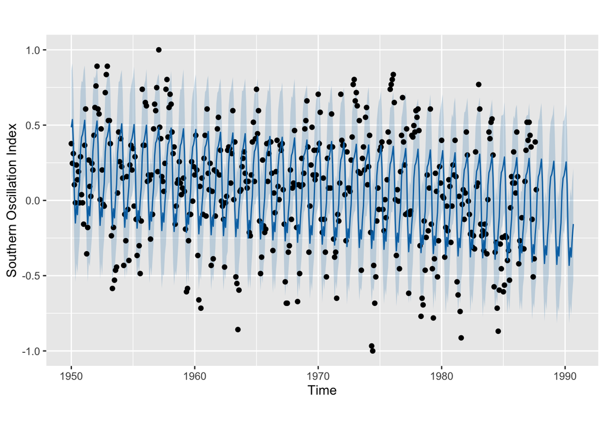

```r
plot(model,prediction, main = "SOI with Prediction", xlab = "Time", ylab = "Southern Oscillation Index")
```

2.6 Use *prophet_plot_components* to see the predicted data broken down into trend and yearly seasonality.

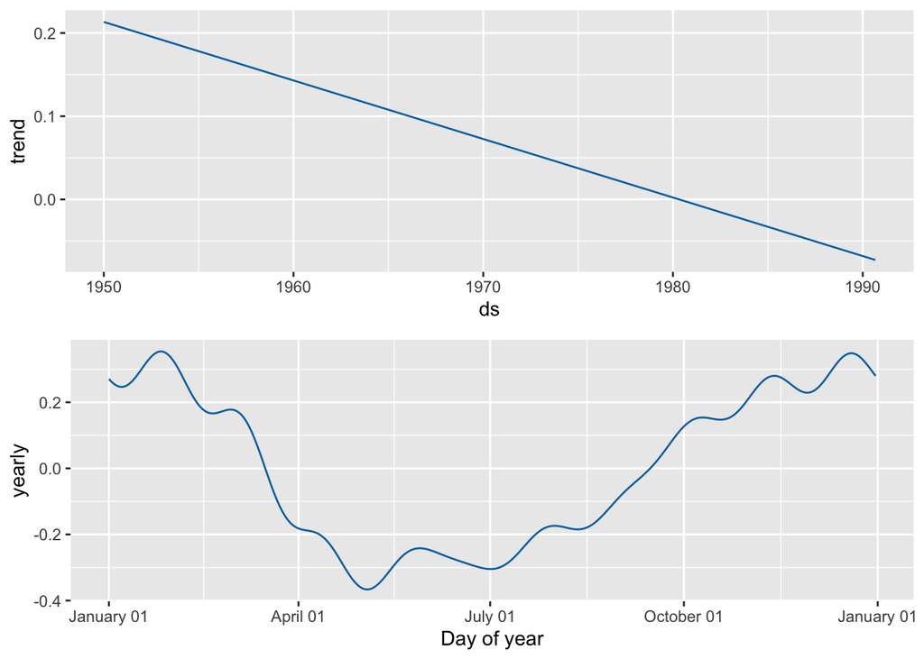

```r
prophet_plot_components(model, prediction) #there is a downward trend used for our prediction
```

```r
dyplot.prophet(model, prediction, main = "Preditcted vs. Actual data Dygraph", xlab = "Time", ylab = "SOI")%>%
  dyRangeSelector(dateWindow = c("1950-01-01", "1970-01-01"))
```

[interactive chart not shown]

This interactive plot of the forecast allows us to hover the mouse over data points and see the actual vs. predicted data.

2.7 Diagnostic checking We run diagnostic checking with **cross validation**, using the first 10 years (3650 days) as the initial training period and specify the forecast horizon as 1 year.

```r
soi.cv <- cross_validation(model, initial =3650, period = 180, horizon = 365, units = 'days')
```

```
## Making 55 forecasts with cutoffs between 1960-01-21 and 1986-09-01
```

```r
head(soi.cv)
```

```
##        y         ds        yhat  yhat_lower yhat_upper     cutoff
## 1  0.432 1960-02-01  0.39813757  0.02906455  0.7757529 1960-01-21
## 2  0.202 1960-03-01  0.27331650 -0.11206612  0.6463818 1960-01-21
## 3 -0.366 1960-04-01 -0.05209518 -0.43793226  0.3380837 1960-01-21
## 4 -0.661 1960-05-01 -0.20143103 -0.58044113  0.1416076 1960-01-21
## 5  0.093 1960-06-01 -0.13083817 -0.46977223  0.2173472 1960-01-21
## 6 -0.716 1960-07-01 -0.11043258 -0.45507761  0.2582212 1960-01-21
```

```r
soi.p <- performance_metrics(soi.cv) #gives statistics of the prediction performance including Mean Squared Error(MSE), Root Mean Squared Error(RMSE), etc. and coverage of the yhat_lower and yhat_upper estimates.
head(soi.p)
```

```
##   horizon        mse      rmse       mae     mape     mdape     smape  coverage
## 1 38 days 0.09447734 0.3073717 0.2482811 2.119188 0.6604505 0.9456550 0.7575758
## 2 39 days 0.09458459 0.3075461 0.2475135 2.114653 0.6428302 0.9387728 0.7424242
## 3 40 days 0.09161693 0.3026829 0.2427863 2.126651 0.6604505 0.9388884 0.7575758
## 4 41 days 0.09040098 0.3006676 0.2403681 2.100983 0.6472539 0.9156233 0.7575758
## 5 43 days 0.09029782 0.3004960 0.2397878 2.088079 0.6299744 0.9076816 0.7575758
## 6 44 days 0.08489258 0.2913633 0.2321393 2.082118 0.6299744 0.9048245 0.7878788
```

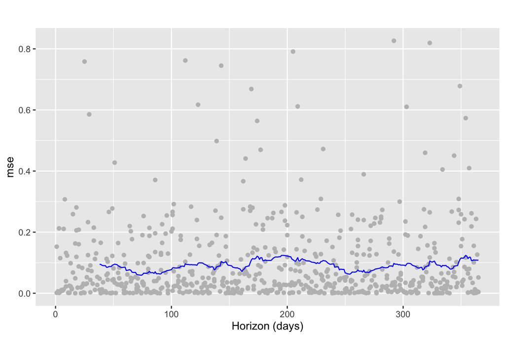

```r
plot_cross_validation_metric(soi.cv, metric = "mse")
```

The metric I used here is “Mean Squared Error” represented as the dots on the graph. The blue line shows the MSE, where the mean is taken over a rolling window of the predictions in df.soi with default 10%. For this forecast the MSEs are around 0.1 somewhat consistently for predictions over the whole year.

2.8 Repeating 2.2 to 2.7 with weekly seasonality.

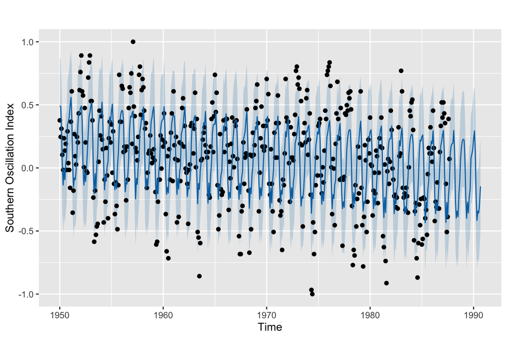

```r
model1 = prophet(soi.df, weekly.seasonality = TRUE, daily.seasonality = FALSE)
future1 = make_future_dataframe(model, periods=36, freq="month")
prediction1 = predict(model1, forecast)
plot(model1,prediction1, main = "SOI with Prediction (weekly seasonality)", xlab = "Time", ylab = "Southern Oscillation Index")
```

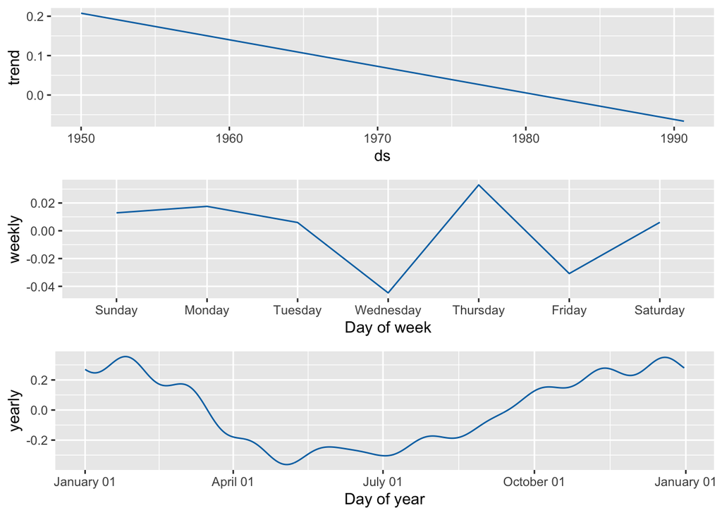

```r
prophet_plot_components(model1, prediction1) #there is a downward trend used for our prediction
```

```r
dyplot.prophet(model1, prediction1, main = "Preditcted vs. Actual data Dygraph", xlab = "Time", ylab = "SOI")%>%
  dyRangeSelector(dateWindow = c("1950-01-01", "1970-01-01"))
```

[interactive chart not shown]

```r
soi.cv1 <- cross_validation(model, initial =3650, period = 180, horizon = 365, units = 'days')
```

```
## Making 55 forecasts with cutoffs between 1960-01-21 and 1986-09-01
```

```r
head(soi.cv1)
```

```
##        y         ds        yhat  yhat_lower yhat_upper     cutoff
## 1  0.432 1960-02-01  0.39813757  0.01347277  0.7664820 1960-01-21
## 2  0.202 1960-03-01  0.27331650 -0.09210476  0.6298387 1960-01-21
## 3 -0.366 1960-04-01 -0.05209518 -0.41767992  0.3062430 1960-01-21
## 4 -0.661 1960-05-01 -0.20143103 -0.57697514  0.1559422 1960-01-21
## 5  0.093 1960-06-01 -0.13083817 -0.49646035  0.2323469 1960-01-21
## 6 -0.716 1960-07-01 -0.11043258 -0.45418808  0.2620539 1960-01-21
```

```r
soi.p1 <- performance_metrics(soi.cv1) #gives statistics of the prediction performance including Mean Squared Error(MSE), Root Mean Squared Error(RMSE), etc. and coverage of the yhat_lower and yhat_upper estimates.
head(soi.p1)
```

```
##   horizon        mse      rmse       mae     mape     mdape     smape  coverage
## 1 38 days 0.09447734 0.3073717 0.2482811 2.119188 0.6604505 0.9456550 0.7272727
## 2 39 days 0.09458459 0.3075461 0.2475135 2.114653 0.6428302 0.9387728 0.7272727
## 3 40 days 0.09161693 0.3026829 0.2427863 2.126651 0.6604505 0.9388884 0.7424242
## 4 41 days 0.09040098 0.3006676 0.2403681 2.100983 0.6472539 0.9156233 0.7424242
## 5 43 days 0.09029782 0.3004960 0.2397878 2.088079 0.6299744 0.9076816 0.7424242
## 6 44 days 0.08489258 0.2913633 0.2321393 2.082118 0.6299744 0.9048245 0.7727273
```

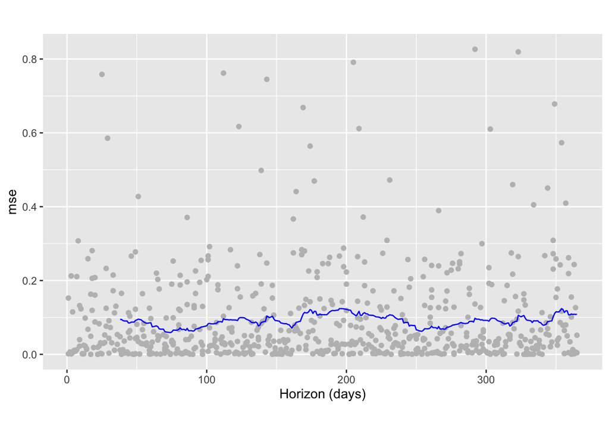

```r
plot_cross_validation_metric(soi.cv1, metric = "mse")
```

Apart from the additional observation on weekly seasonality, our predictions are not too different from the first time. The MSE is still at 0.1 which does not show significant improvement from the other model.

## Reference

Website for information on SOI and how it is calculated:

https://www.ncei.noaa.gov/access/monitoring/enso/soi

Examples and instruction on Prophet forecasting system:

https://facebook.github.io/prophet/docs/diagnostics.html#cross-validation